# Homework 2

Felipe Dessoy Caraballo

02/05/2020

#Question 1A

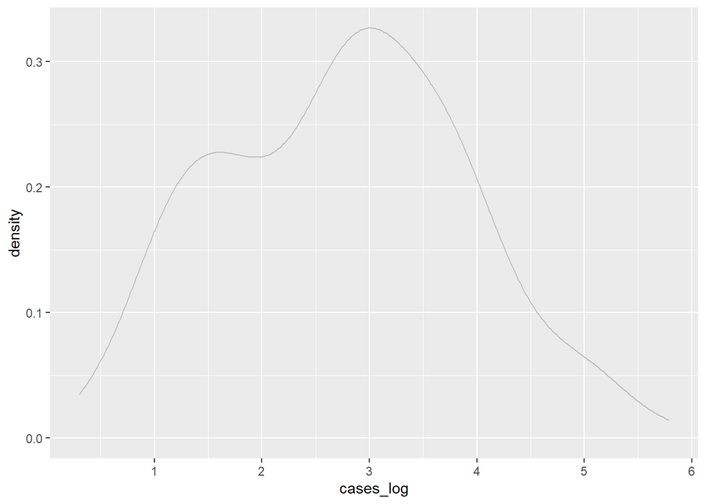

```r
rawData <- read.csv("https://raw.githubusercontent.com/FjjDessoyCaraballo/LU_QA_2020/master/Datasets/Corona_mergedV-Dem.csv")

library(ggplot2)
library(GGally)

ggplot(rawData, aes(x=cases_log))+
  geom_density(col='grey')
```

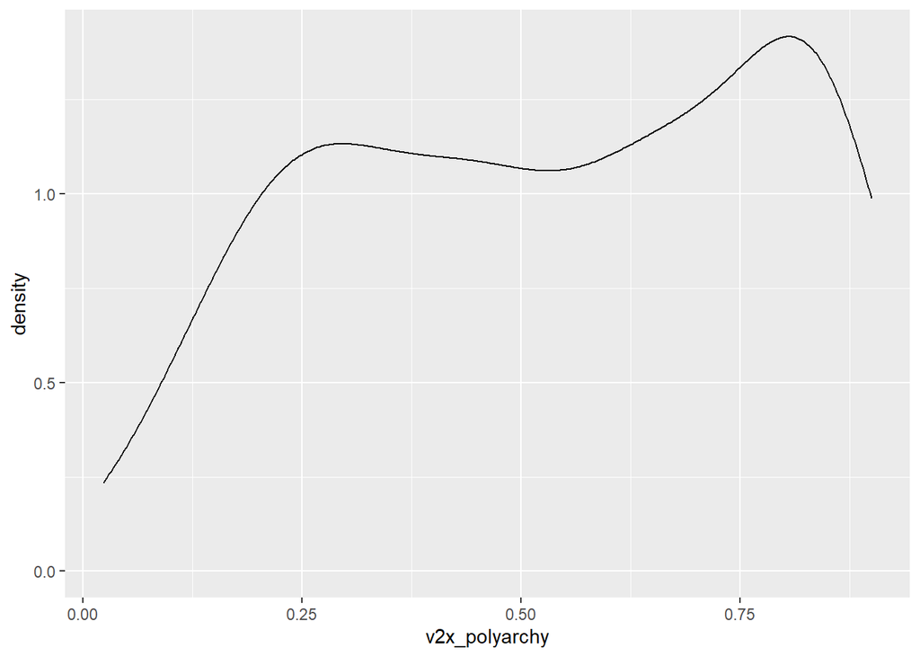

```r
ggplot(rawData, aes(x=v2x_polyarchy))+
  geom_density(col='black')
```

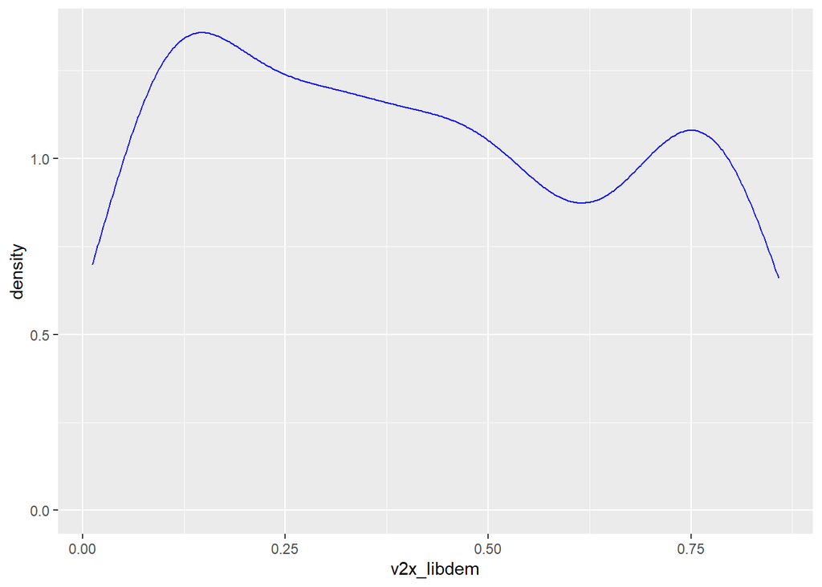

```r
ggplot(rawData, aes(x=v2x_libdem))+
  geom_density(col='blue')
```

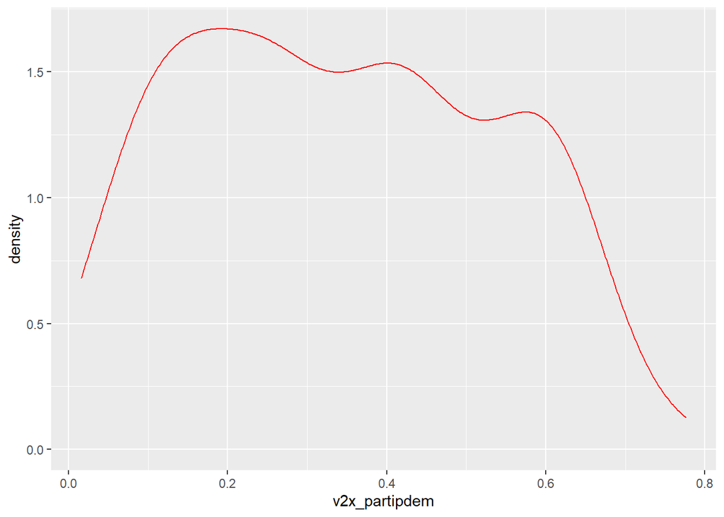

```r
ggplot(rawData, aes(x=v2x_partipdem))+
  geom_density(col='red')
```

#Question 1B

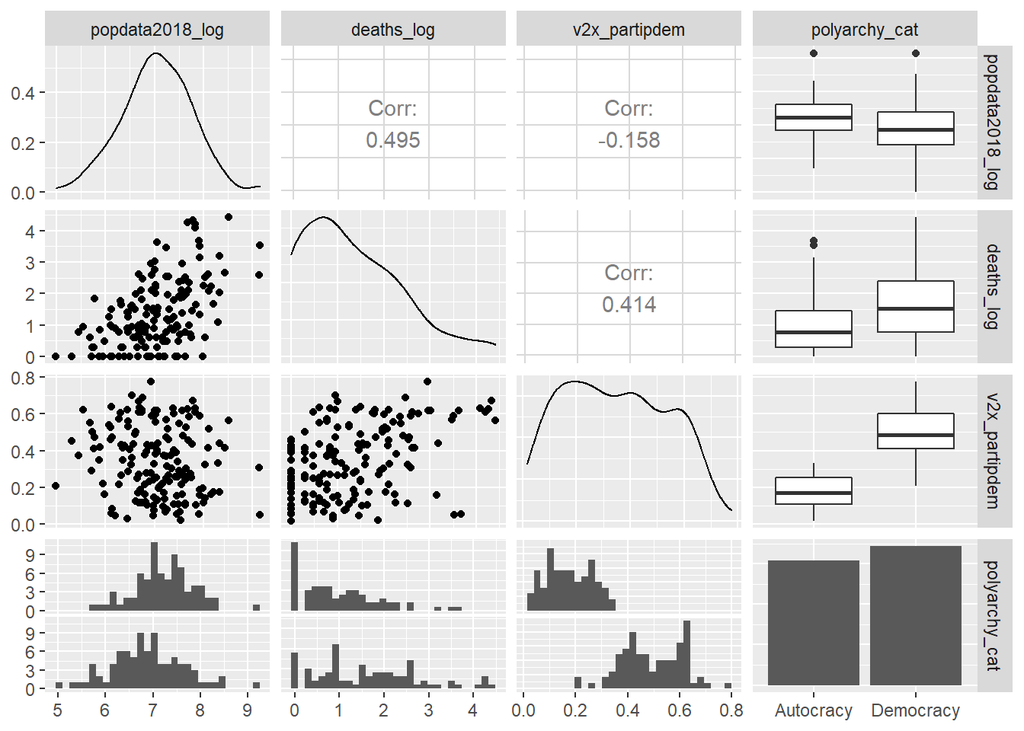

```r
rawData$polyarchy_cat=ifelse(rawData$v2x_polyarchy> .5, "Democracy", "Autocracy")
rawData$polyarchy_cat<-factor(rawData$polyarchy_cat)
ggpairs(rawData, columns = c("popdata2018_log", "deaths_log", "v2x_partipdem", "polyarchy_cat"))
```

#Question 1C

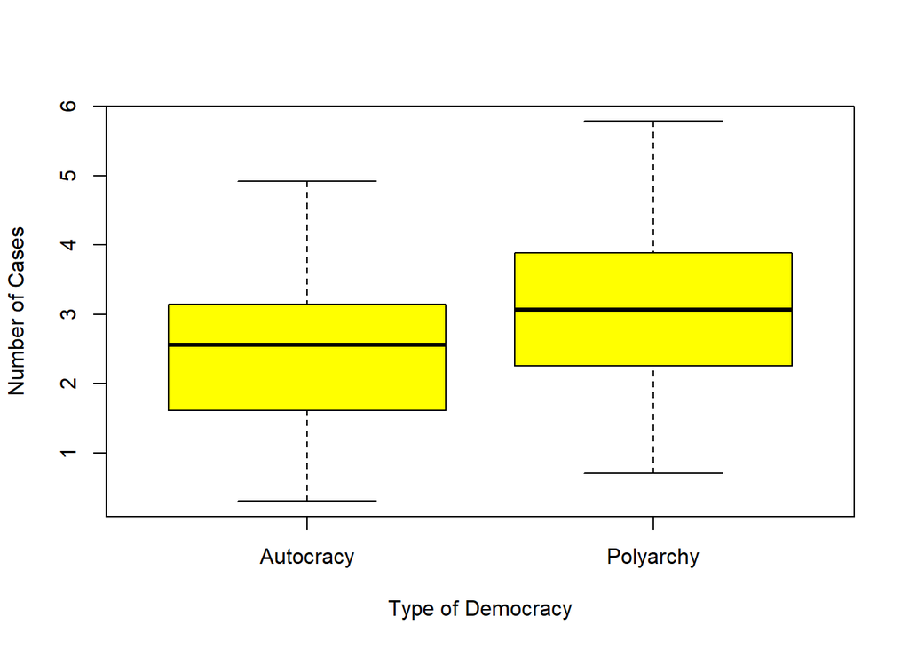

```r
#Polyarchy

rawData$polyarchy_cat=ifelse(rawData$v2x_polyarchy> .5, "Polyarchy", "Autocracy")
rawData$polyarchy_cat<-factor(rawData$polyarchy_cat)
boxplot(rawData$cases_log~rawData$polyarchy_cat,
        col='yellow', xlab='Type of Democracy',
        ylab='Number of Cases')
```

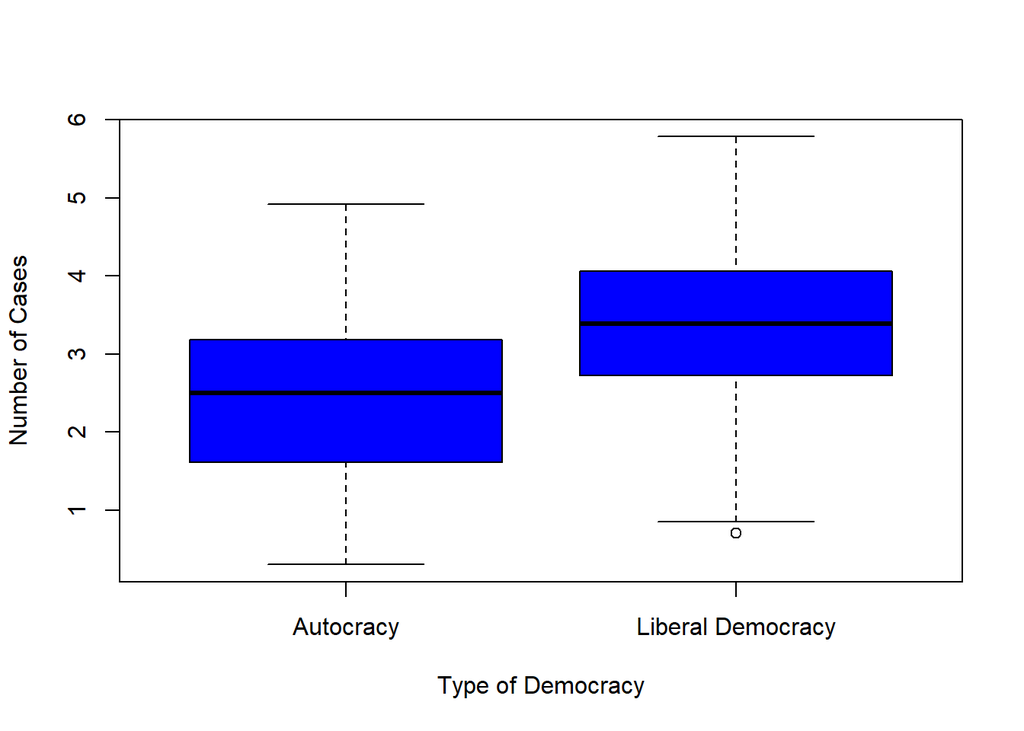

```r
#Liberal Democracy

rawData$libdem_cat=ifelse(rawData$v2x_libdem > .5, "Liberal Democracy", "Autocracy")
rawData$libdem_cat<-factor(rawData$libdem_cat)
boxplot(rawData$cases_log~rawData$libdem_cat,
        col='blue',
        xlab='Type of Democracy', ylab='Number of Cases')
```

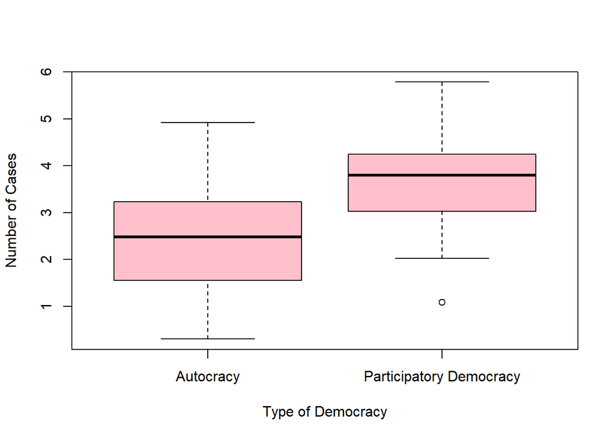

```r
#Participatory Democracy

rawData$v2x_partipdem_cat=ifelse(rawData$v2x_partipdem > .5, "Participatory Democracy", "Autocracy")
rawData$v2x_partipdem_cat<-factor(rawData$v2x_partipdem_cat)
boxplot(rawData$cases_log~rawData$v2x_partipdem_cat,
        col='pink',
        xlab='Type of Democracy', ylab='Number of Cases')
```

#Question 1D1

```r
OLS_m1=lm(cases_log~v2x_polyarchy, data=rawData)
summary(OLS_m1)
```

```
##
## Call:
## lm(formula = cases_log ~ v2x_polyarchy, data = rawData)
##
## Residuals:
##      Min       1Q   Median       3Q      Max
## -2.31471 -0.69695 -0.00291  0.79433  2.83502
##
## Coefficients:
##               Estimate Std. Error t value Pr(>|t|)
## (Intercept)     1.9619     0.2034   9.646  < 2e-16 ***
## v2x_polyarchy   1.4940     0.3450   4.330 2.61e-05 ***
## ---
## Signif. codes:  0 '***' 0.001 '**' 0.01 '*' 0.05 '.' 0.1 ' ' 1
##
## Residual standard error: 1.091 on 161 degrees of freedom
## Multiple R-squared:  0.1043, Adjusted R-squared:  0.09876
## F-statistic: 18.75 on 1 and 161 DF,  p-value: 2.608e-05
```

So far, our standar error is low and the regression line is a fit. That said, our variables here show us a positive correlation between polyarchy and the number of COVID-19 cases. However, this correlation might not be causal.

#Question 1D2

```r
OLS_m2=lm(cases_log~v2x_libdem, data=rawData)
summary(OLS_m2)
```

```
##
## Call:
## lm(formula = cases_log ~ v2x_libdem, data = rawData)
##
## Residuals:
##      Min       1Q   Median       3Q      Max
## -2.32986 -0.67076  0.06097  0.79488  2.77711
##
## Coefficients:
##             Estimate Std. Error t value Pr(>|t|)
## (Intercept)   2.0592     0.1605  12.828  < 2e-16 ***
## v2x_libdem    1.6922     0.3302   5.125 8.44e-07 ***
## ---
## Signif. codes:  0 '***' 0.001 '**' 0.01 '*' 0.05 '.' 0.1 ' ' 1
##
## Residual standard error: 1.069 on 161 degrees of freedom
## Multiple R-squared:  0.1402, Adjusted R-squared:  0.1349
## F-statistic: 26.26 on 1 and 161 DF,  p-value: 8.441e-07
```

Exchanging the polyarchy variable to the liberal democracy variable, we see an even lower standard error of 0.16, and our regression line has shown again a positive correlation to both independent and dependent variable. However, the causality link is still missing without a proper R².